# 21. 계층적 모델

- 많은 계층적 모델은 유사한 구조를 가짐
- 데이터는 소수의 하이퍼매개변수에 의존
- 로짓정규-이항 계층 모델을 사용하여 2개의 초매개변수와 13개의 매개변수가 있는 문제

```python
import matplotlib.pyplot as plt
from empiricaldist import Cdf
from empiricaldist import Pmf
from os.path import basename, exists
```

```python
def legend(**options):

    handles, labels = plt.gca().get_legend_handles_labels()
    if len(labels):
        plt.legend(**options)

def decorate(**options):
    plt.gca().set(**options)
    legend()
    plt.tight_layout()
```

```python
def compare_cdf(pmf, sample):
    pmf.make_cdf().step(label='grid')
    Cdf.from_seq(sample).plot(label='mcmc')
    print(pmf.mean(), sample.mean())
    decorate()

def make_pmf(ps, qs, name):
    pmf = Pmf(ps, qs)
    pmf.normalize()
    pmf.index.name = name
    return pmf
```

## 21.01. 심장병 데이터

```python
import os
import pandas as pd
import numpy as np

from os.path import basename, exists

def download(url):
    filename = basename(url)
    if not exists(filename):
        from urllib.request import urlretrieve
        local, _ = urlretrieve(url, filename)
        print('Downloaded ' + local)
```

```python
download('https://github.com/AllenDowney/BayesianInferencePyMC/raw/main/DeathHeartAttackManhattan.csv')
```

```python
df = pd.read_csv('DeathHeartAttackManhattan.csv')
df
```

|  | Hospital | Cases | Deaths | Death % |
| --- | --- | --- | --- | --- |
| 0 | Bellevue Hospital Center | 129 | 4 | 3.101 |
| 1 | Harlem Hospital Center | 35 | 1 | 2.857 |
| 2 | Lenox Hill Hospital | 228 | 18 | 7.894 |
| 3 | Metropolitan Hospital Center | 84 | 7 | 8.333 |
| 4 | Mount Sinai Beth Israel | 291 | 24 | 8.247 |
| 5 | Mount Sinai Hospital | 270 | 16 | 5.926 |
| 6 | Mount Sinai Roosevelt | 46 | 6 | 13.043 |
| 7 | Mount Sinai St. Luke’s | 293 | 19 | 6.485 |
| 8 | NYU Hospitals Center | 241 | 15 | 6.224 |
| 9 | NYP Hospital - Allen Hospital | 105 | 13 | 12.381 |
| 10 | NYP Hospital - Columbia Presbyterian Center | 353 | 25 | 7.082 |
| 11 | NYP Hospital - New York Weill Cornell Center | 250 | 11 | 4.400 |
| 12 | NYP/Lower Manhattan Hospital | 41 | 4 | 9.756 |

```python
data_ns = df['Cases'].values.astype(int)
data_ks = df['Deaths'].values.astype(int)
```

- `Cases` : 각 병원에서 치료받은 환자 수
- `Deaths` : 사망한 환자 수

## 21.02. `PyMC3`을 통한 접근

#### 각 병원의 사망률을 추정하는 동시에 병원 전체의 사망률 분포를 추정하는 계층적 모델

```python
import pymc3 as pm
```

```python
def make_model():

    with pm.Model() as model:
        mu = pm.Normal('mu', 0, 2)
        sigma = pm.HalfNormal('sigma', sigma=1)
        xs = pm.LogitNormal('xs', mu=mu, sigma=sigma, shape=len(data_ns))
        ks = pm.Binomial('ks', n=data_ns, p=xs, observed=data_ks)
    return model
```

```python
%time model = make_model()
```

```
Wall time: 342 ms
```

```python
model
```

$$ \begin{array}{rcl} \text{mu} &\sim & \text{Normal}\\\text{sigma_log__} &\sim & \text{TransformedDistribution}\\\text{xs_logodds__} &\sim & \text{TransformedDistribution}\\\text{sigma} &\sim & \text{HalfNormal}\\\text{xs} &\sim & \text{LogitNormal}\\\text{ks} &\sim & \text{Binomial} \end{array} $$

[figure not shown]

#### 사전예측분포표본 추출 & 갱신 및 사후분포 계산

```python
with model:
    pred = pm.sample_prior_predictive(1000)
    %time trace = pm.sample(500, target_accept=0.97)
```

100.00% [6000/6000 03:39<00:00 Sampling 4 chains, 18 divergences]

```
Sampling 4 chains for 1_000 tune and 500 draw iterations (4_000 + 2_000 draws total) took 233 seconds.
There were 3 divergences after tuning. Increase `target_accept` or reparameterize.
The acceptance probability does not match the target. It is 0.9151150425170346, but should be close to 0.97. Try to increase the number of tuning steps.
There were 10 divergences after tuning. Increase `target_accept` or reparameterize.
The acceptance probability does not match the target. It is 0.9296908331399019, but should be close to 0.97. Try to increase the number of tuning steps.
There were 5 divergences after tuning. Increase `target_accept` or reparameterize.
The estimated number of effective samples is smaller than 200 for some parameters.
```

```
Wall time: 3min 58s
```

#### 매개변수별 사후주변분포

```python
import arviz as az
```

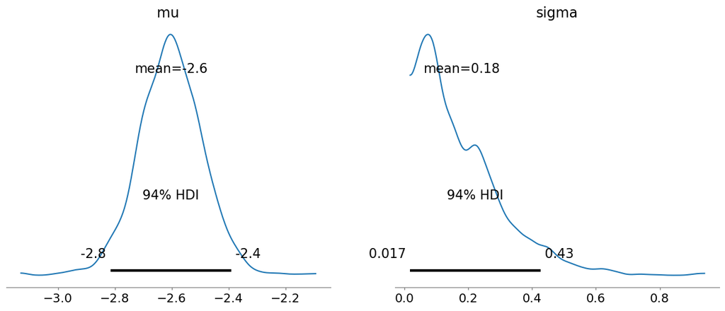

```python
with model:
    az.plot_posterior(trace, var_names=['mu', 'sigma'])
```

```python
trace_xs = trace['xs'].transpose()
trace_xs.shape
```

```
(13, 2000)
```

#### `xs`의 사후분포

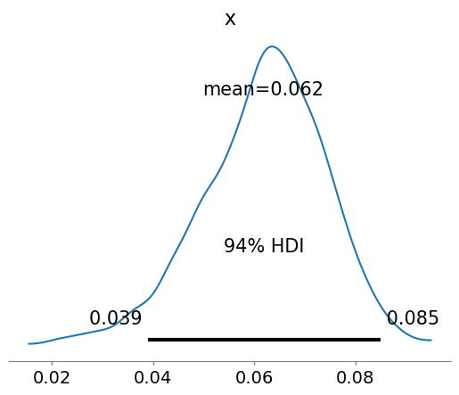

```python
with model:
    az.plot_posterior(trace_xs[0])
```

## 02.02. 그리드 방법론을 통한 접근

#### `mu`에 대한 정규사전분포

```python
import numpy as np
from scipy.stats import norm
```

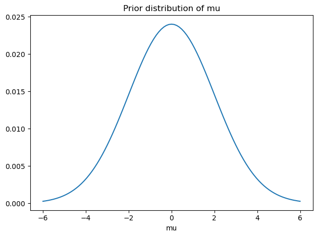

```python
mus = np.linspace(-6, 6, 101)
ps = norm.pdf(mus, 0, 2)
prior_mu = make_pmf(ps, mus, 'mu')

prior_mu.plot()
decorate(title='Prior distribution of mu')
```

#### `sigma`에 대한 사전분포

```python
from scipy.stats import logistic
```

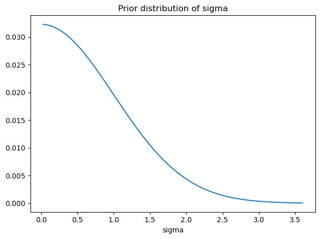

```python
sigmas = np.linspace(0.03, 3.6, 90)
ps = norm.pdf(sigmas, 0, 1)
prior_sigma = make_pmf(ps, sigmas, 'sigma')

prior_sigma.plot()
decorate(title='Prior distribution of sigma')
```

#### `PyMC3`의 매개변수별 사전분포와 비교

```
2.6020852139652106e-18 0.06735021717349843
```

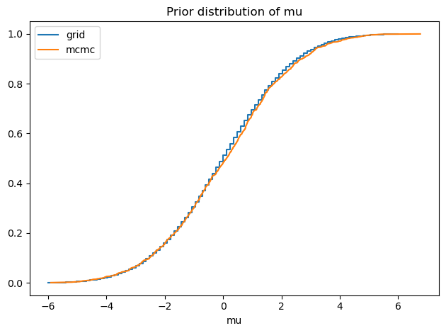

```python
compare_cdf(prior_mu, pred['mu'])
decorate(title='Prior distribution of mu')
```

```
0.8033718951689776 0.8013124892993277
```

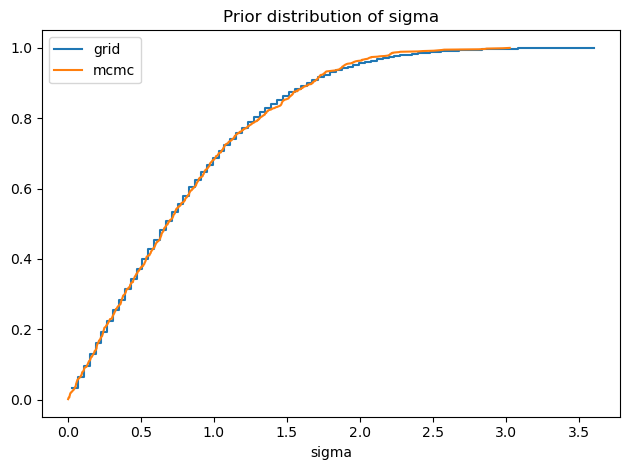

```python
compare_cdf(prior_sigma, pred['sigma'])
decorate(title='Prior distribution of sigma')
```

## 02.03. 사전결합분포

```python
def make_joint(prior_x, prior_y):
    X, Y = np.meshgrid(prior_x.ps, prior_y.ps, indexing='ij')
    hyper = X * Y
    return hyper
```

```python
prior_hyper = make_joint(prior_mu, prior_sigma)
prior_hyper.shape
```

```
(101, 90)
```

```python
import pandas as pd
from utils import plot_contour
```

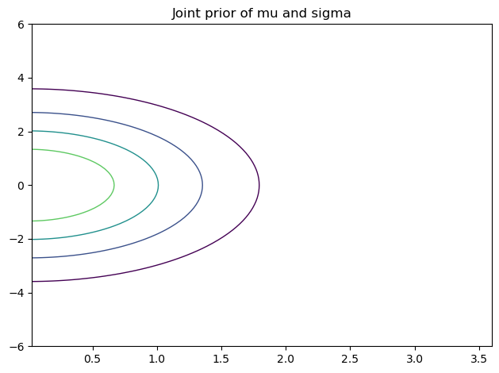

```python
plot_contour(pd.DataFrame(prior_hyper, index=mus, columns=sigmas))
decorate(title="Joint prior of mu and sigma")
```

## 02.04. `x`와 초매개변수의 결합분포

### 각 초매개변수 조합별, `x`의 분포계산

```python
xs = np.linspace(0.01, 0.99, 295)
```

```python
from scipy.special import logit
```

```python
M, S, X = np.meshgrid(mus, sigmas, xs, indexing='ij')
LO = logit(X)
LO.sum()
```

```
-6.440927791118156e-10
```

```python
from scipy.stats import norm
```

```python
%time normpdf = norm.pdf(LO, M, S)
normpdf.sum()
```

```
Wall time: 125 ms
```

```
214125.5678798693
```

```python
%%time

z = (LO-M) / S
normpdf = np.exp(-z**2/2)
```

```
Wall time: 67.3 ms
```

```python
totals = normpdf.sum(axis=2)
totals.shape
```

```
(101, 90)
```

- 각 값을, 해당 값이 속한 차원의 합으로 나누는 정규화

```python
def divide(x, y):
    out = np.zeros_like(x)
    return np.divide(x, y, out=out, where=(y!=0))
```

```python
shape = totals.shape + (1,)
normpdf = divide(normpdf, totals.reshape(shape))
normpdf.shape
```

```
(101, 90, 295)
```

### 초매개변수 조합과 `x`의 의 결합분포를 곱하여, 최종적인 사전결합분포를 계산

```python
def make_prior(hyper):

    shape = hyper.shape + (1,)
    prior = normpdf * hyper.reshape(shape)

    return prior
```

```python
%time prior = make_prior(prior_hyper)
prior.sum()
```

```
Wall time: 6.02 ms
```

```
0.999937781278039
```

### `mu`, `sigma`, `x`의 개별 사전분포

```python
def marginal(joint, axis):
    axes = [i for i in range(3) if i != axis]
    return joint.sum(axis=tuple(axes))
```

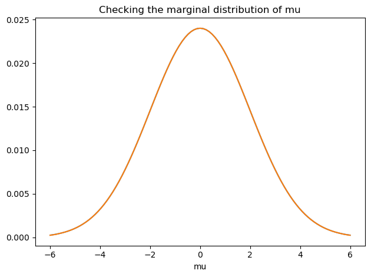

```python
prior_mu.plot()
marginal_mu = Pmf(marginal(prior, 0), mus)
marginal_mu.plot()
decorate(title='Checking the marginal distribution of mu')
```

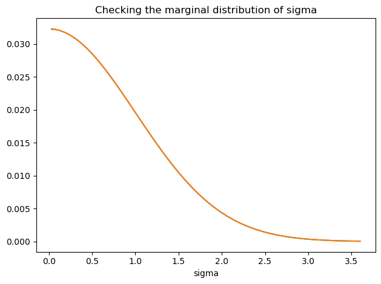

```python
prior_sigma.plot()
marginal_sigma = Pmf(marginal(prior, 1), sigmas)
marginal_sigma.plot()
decorate(title='Checking the marginal distribution of sigma')
```

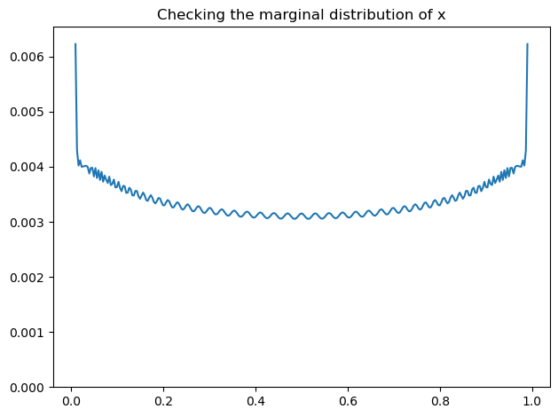

```python
marginal_x = Pmf(marginal(prior, 2), xs)
marginal_x.plot()
decorate(title='Checking the marginal distribution of x', ylim=[0, np.max(marginal_x) * 1.05])
```

#### `PyMC3`의 개별 사전분포와의 비교

```python
pred_xs = pred['xs'].transpose()
pred_xs.shape
```

```
(13, 1000)
```

```
0.49996889063901967 0.5118555039997851
```

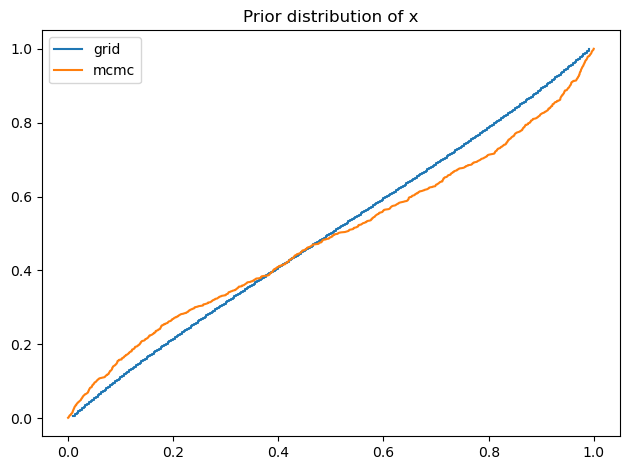

```python
compare_cdf(marginal_x, pred_xs[0])
decorate(title='Prior distribution of x')
```

#### `mu`와 `sigma`의 사전결합분포

```python
def get_hyper(joint):
    return joint.sum(axis=2)
```

```python
hyper = get_hyper(prior)
```

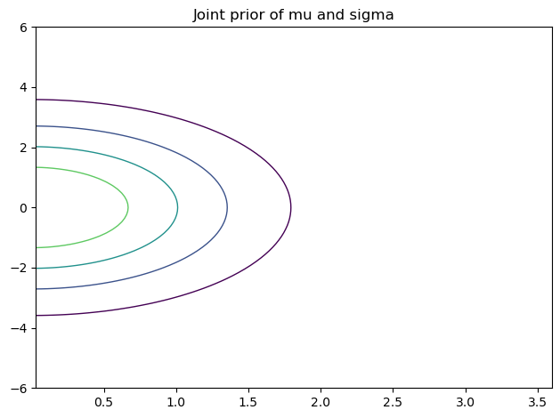

```python
plot_contour(pd.DataFrame(hyper, index=mus, columns=sigmas))
decorate(title="Joint prior of mu and sigma")
```

## 02.05. 갱신

#### 각 환자수와, 사망자수의 데이터별 가능도 계산 및 갱신

```python
data_ks, data_ns
```

```
(array([ 4,  1, 18,  7, 24, 16,  6, 19, 15, 13, 25, 11,  4]),
 array([129,  35, 228,  84, 291, 270,  46, 293, 241, 105, 353, 250,  41]))
```

```python
from scipy.stats import binom
```

```python
data_k = data_ks[0]
data_n = data_ns[0]

like_x = binom.pmf(data_k, data_n, xs)
like_x.shape
```

```
(295,)
```

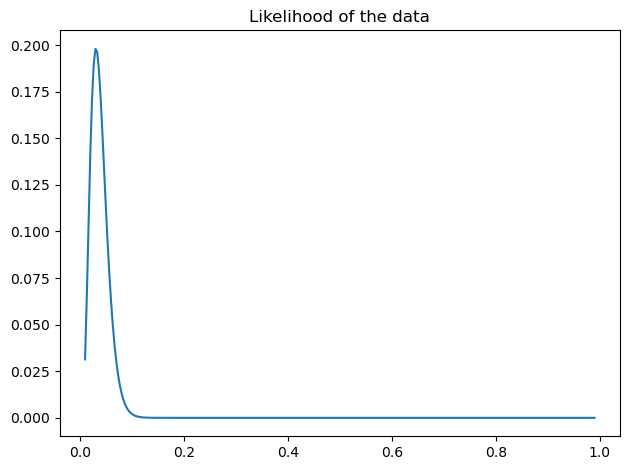

```python
plt.plot(xs, like_x)
decorate(title='Likelihood of the data')
```

```python
def update(prior, data):
    n, k = data
    like_x = binom.pmf(k, n, xs)
    posterior = prior * like_x
    posterior /= posterior.sum()
    return posterior
```

```python
data = data_n, data_k
%time posterior = update(prior, data)
```

```
Wall time: 10 ms
```

## 02.06. 연속적인 갱신

#### 각 갱신 후, 초매개변수의 사후 분포를 추출하고, 이를 사용하여 다음 업데이트에 대한 사전 분포를 생성

- **순서에 따라 계산이 진행되기 때문에, 마지막에 계산된 병원의 데이터를 활용한 갱신에 의하여 나온 사후분포는 정확하지만**

  **그 이전에 계산된 사후분포들은 다소 부정확할 수 있음**

```python
def multiple_updates(prior, ns, ks):
    for data in zip(ns, ks):
        print(data)
        posterior = update(prior, data)
        hyper = get_hyper(posterior)
        prior = make_prior(hyper)
    return posterior
```

```python
%time posterior = multiple_updates(prior, data_ns, data_ks)
```

```
(129, 4)
(35, 1)
(228, 18)
(84, 7)
(291, 24)
(270, 16)
(46, 6)
(293, 19)
(241, 15)
(105, 13)
(353, 25)
(250, 11)
(41, 4)
Wall time: 316 ms
```

#### `PyMC3`의 결고와 비교

```
-2.6478808810110763 -2.6032677684384407
```

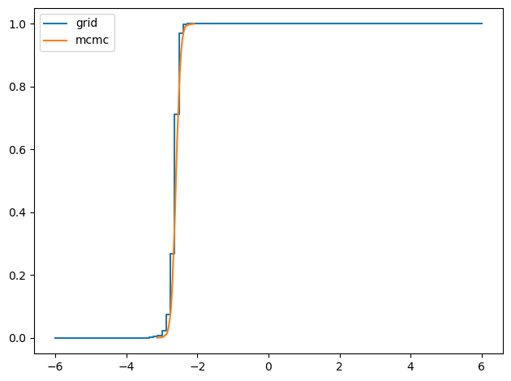

```python
marginal_mu = Pmf(marginal(posterior, 0), mus)
compare_cdf(marginal_mu, trace['mu'])
```

```
0.19272226451430116 0.17960116541103846
```

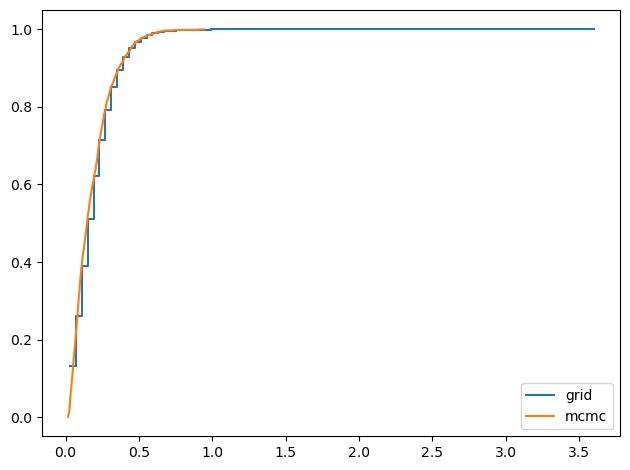

```python
marginal_sigma = Pmf(marginal(posterior, 1), sigmas)
compare_cdf(marginal_sigma, trace['sigma'])
```

```
0.07330826956150181 0.07226031494102851
```

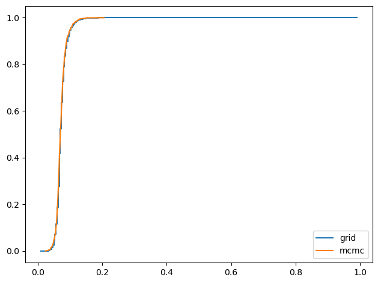

```python
marginal_x = Pmf(marginal(posterior, 2), xs)
compare_cdf(marginal_x, trace_xs[-1])
```

## 02.07. 병렬갱신

#### 갱신을 한 번에 하나씩 수행하는 것은 옳지 않지만, 인사이트를 얻을 수 있음

#### 초매개변수의 가능도

```python
def compute_hyper_likelihood(ns, ks):
    shape = ns.shape + mus.shape + sigmas.shape
    hyper_likelihood = np.empty(shape)

    for i, data in enumerate(zip(ns, ks)):
        print(data)
        n, k = data
        like_x = binom.pmf(k, n, xs)
        posterior = normpdf * like_x
        hyper_likelihood[i] = get_hyper(posterior)
    return hyper_likelihood
```

```python
%time hyper_likelihood = compute_hyper_likelihood(data_ns, data_ks)
```

```
(129, 4)
(35, 1)
(228, 18)
(84, 7)
(291, 24)
(270, 16)
(46, 6)
(293, 19)
(241, 15)
(105, 13)
(353, 25)
(250, 11)
(41, 4)
Wall time: 141 ms
```

```python
hyper_likelihood.shape
```

```
(13, 101, 90)
```

```python
%time hyper_likelihood_all = hyper_likelihood.prod(axis=0)
hyper_likelihood_all.sum()
```

```
Wall time: 0 ns
```

```
1.685854062633571e-14
```

```python
hyper_likelihood_all.shape
```

```
(101, 90)
```

#### 병렬갱신에서의 `i`번째 사전/사후분포

```python
i = 3
data = data_ns[i], data_ks[i]
data
```

```
(84, 7)
```

```python
%time hyper_i = divide(prior_hyper * hyper_likelihood_all, hyper_likelihood[i])
hyper_i.sum()
```

```
Wall time: 0 ns
```

```
4.334428727871695e-17
```

```python
prior_i = make_prior(hyper_i)
```

```python
posterior_i = update(prior_i, data)
```

#### `PyMC3` 결과와의 비교

```python
marginal_mu = Pmf(marginal(posterior_i, 0), mus)
marginal_sigma = Pmf(marginal(posterior_i, 1), sigmas)
marginal_x = Pmf(marginal(posterior_i, 2), xs)
```

```
-2.647880881011078 -2.6032677684384407
```

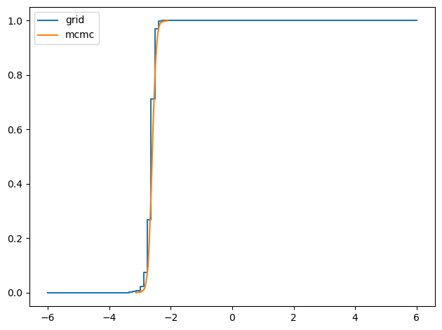

```python
compare_cdf(marginal_mu, trace['mu'])
```

```
0.19272226451430127 0.17960116541103846
```

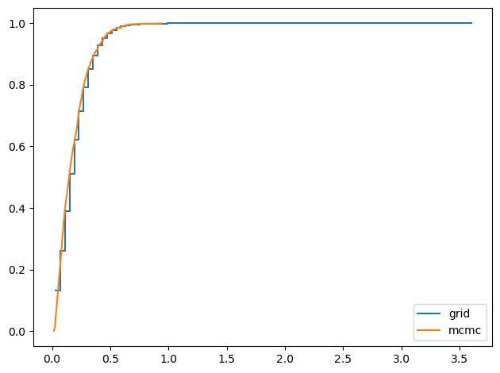

```python
compare_cdf(marginal_sigma, trace['sigma'])
```

```
0.07245354421667904 0.07214960080661861
```

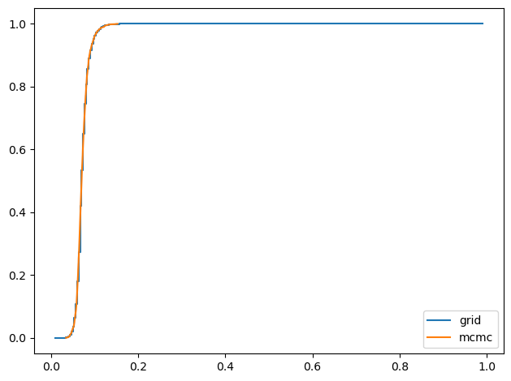

```python
compare_cdf(marginal_x, trace_xs[i])
```

## 02.08. 모든 사후주변분포 계산

```python
def compute_all_marginals(ns, ks):
    shape = len(ns), len(xs)
    marginal_xs = np.zeros(shape)
    numerator = prior_hyper * hyper_likelihood_all

    for i, data in enumerate(zip(ns, ks)):
        hyper_i = divide(numerator, hyper_likelihood[i])
        prior_i = make_prior(hyper_i)
        posterior_i = update(prior_i, data)
        marginal_xs[i] = marginal(posterior_i, 2)

    return marginal_xs
```

```python
%time marginal_xs = compute_all_marginals(data_ns, data_ks)
```

```
Wall time: 305 ms
```

```
0.061236364078224206 0.06178443007926917
0.06653003152551518 0.06657803030200296
0.07267383211481374 0.0724094340966129
0.07245354421667904 0.07214960080661861
0.07430385699796423 0.07387629955977934
0.06606326919655045 0.06615927932515743
0.07774639529896528 0.07652517559124784
0.06788483681522386 0.0679731228401252
0.06723306224279788 0.0674115508479594
0.08183332535205981 0.08077144545708384
0.07003760661997553 0.0697571015622701
0.06136130741477605 0.06167916806856692
0.07330826956150187 0.07226031494102851
```

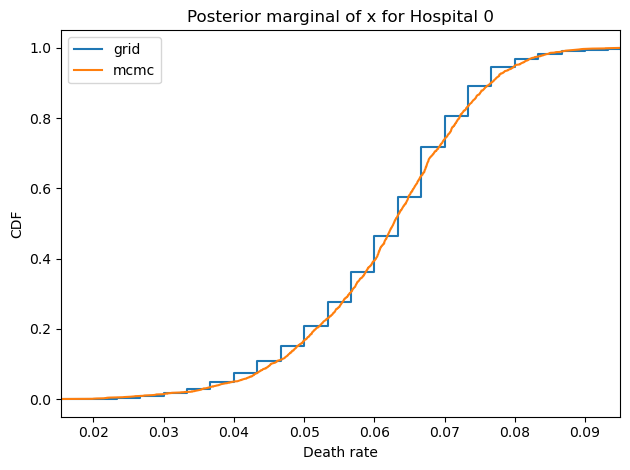

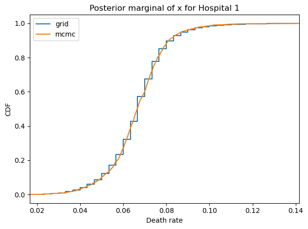

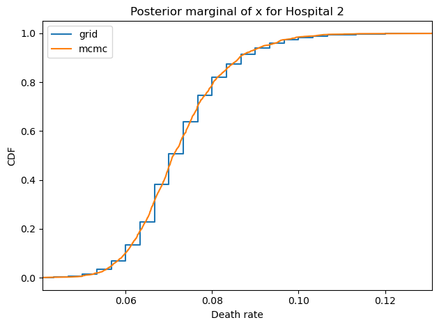

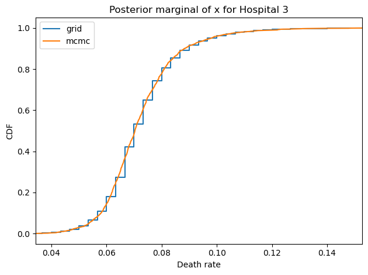

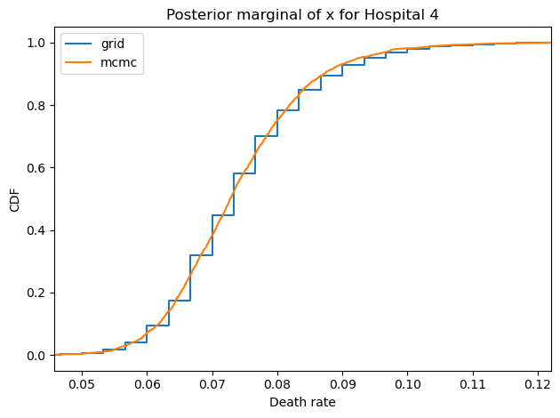

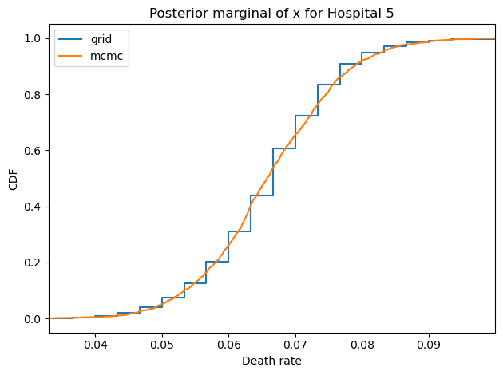

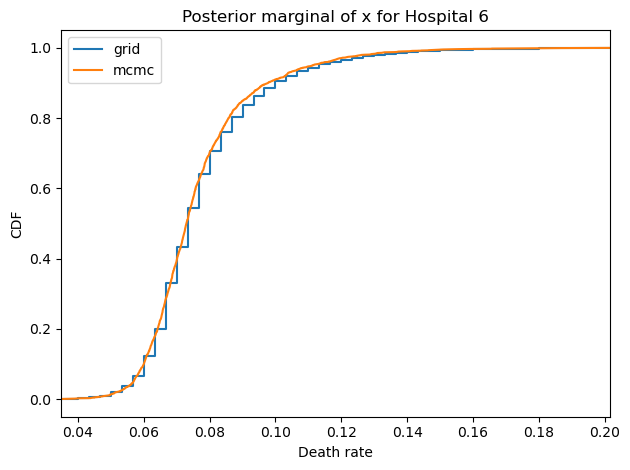

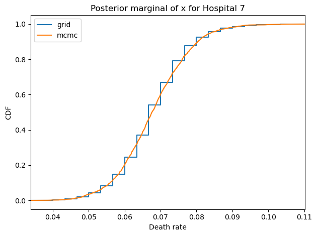

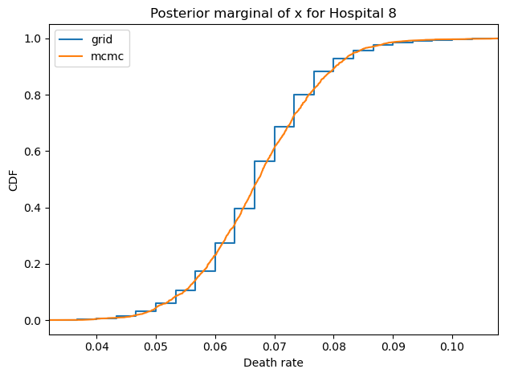

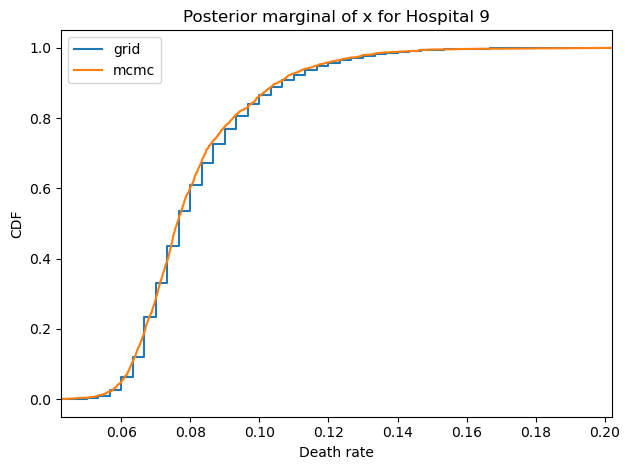

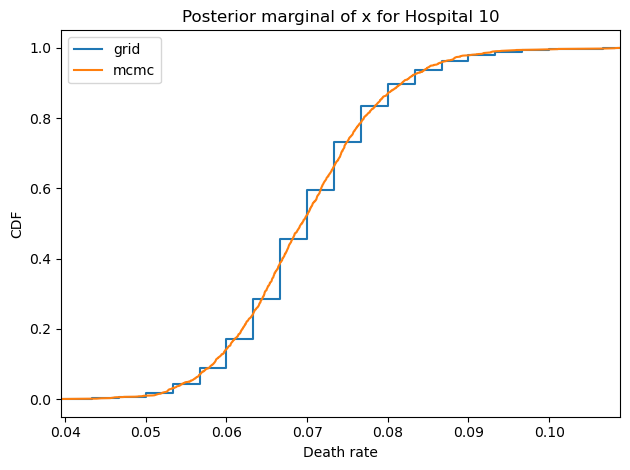

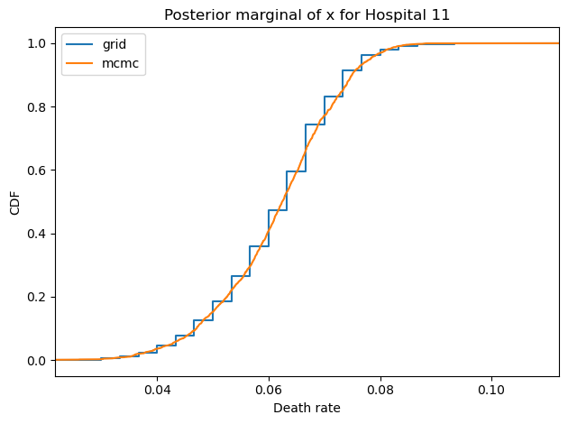

[1 more figures not shown]

```python
for i, ps in enumerate(marginal_xs):
    pmf = Pmf(ps, xs)
    plt.figure()
    compare_cdf(pmf, trace_xs[i])
    decorate(title=f'Posterior marginal of x for Hospital {i}',
             xlabel='Death rate',
             ylabel='CDF',
             xlim=[trace_xs[i].min(), trace_xs[i].max()])
```

#### `PyMC3` 사후주변분포와의 비교

- **성능 차이는 거의 없지만, 연산량과 시간의 측면에서 훨씬 효율적**

```python
for i, ps in enumerate(marginal_xs):
    pmf = Pmf(ps, xs)
    diff = abs(pmf.mean() - trace_xs[i].mean()) / pmf.mean()
    print(diff * 100)
```

```
0.8950008859847641
0.07214602997651684
0.3638146090646763
0.4195010932128594
0.5754175563142038
0.14533057442454425
1.5707734140230794
0.13005264362886237
0.2654774291210312
1.2976130328415667
0.4005063440095263
0.5180147998514283
1.4295176065971342
```